# STAT 687 - Chapter 6

Probability Plotting

Maj Jason Freels

Air Force Institute of Technology

## This chapter explains

STAT 687 - Chapter 6

Applications of probability plots

Basic probability plotting concepts for both complete and censored data

How to analytically linearize a cdf on special plotting scales

How to plot a nonparametric estimate of $F(t)$ on probability paper and how to use such a plot to judge the adequacy of a particular parametric distribution

Analytical and simulation methods of separating useful information from “noise” when using a probability plot to assess the reasonableness of a particular model

Graphical estimates of important reliability characteristics like failure probabilities and distribution quantiles

# Section 6.1|Introduction

## $\S$ 6.1.1 - Purposes of Probability Plots

STAT 687 - Chapter 6

In practical applications probability plots are used to:

- Assess the adequacy of a particular distributional model
- Provide *nonparametric* graphical estimates of probabilities and distribution quantiles
- Obtain graphical estimates of *parametric* model parameters (e.g. by fitting a straight line through the points on a probability plot)
- Display the *results* of a parametric maximum likelihood fit along with the data

In addition, probability plots often reveal information about a population, a process, or data that might otherwise escape detection

## $\S$ 6.1.2 - Prob Plotting Scales: Linearizing a cdf

STAT 687 - Chapter 6

CDF’s from different distributions can appear similar on nonparametric plots

Probability plots use transformed axes to plot a linearized cdf vs $t$

**Basic Idea**

- Invert $F(t_{p})$ to analytically determine the quantile function $t_{p}$
- Transform $F^{-1}(p)$ to obtain a linear plot of the form

$\begin{aligned} y&=m(x)\;+b\\\\ F^{-1}(p)&=m(t_{p})+b \end{aligned}$

# Section 6.2|Linearizing Location-Scale Based Distributions

## $\S$ 6.2.1 - Linearizing the Exponential CDF

STAT 687 - Chapter 6

For $T\sim EXP(\theta,\gamma)$

$F(t_{p})=p=1-\exp\left(-\frac{t_{p}-\gamma}{\theta}\right),\;\;t_{p}\in [0,\infty)$

and

$t_{p}=\ln\left(\frac{1}{1-p}\right)\theta+\gamma$

**What points are being plotted?**

**What is the slope of the best fit line?**

**What is the intercept?**

## Figure 6.1 - Exponential Probability Plot

STAT 687 - Chapter 6

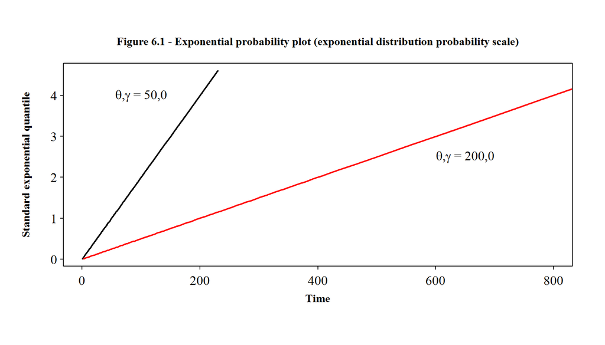

## Figure 6.1 - Exponential Probability Plot

STAT 687 - Chapter 6

```r
par(family="serif",font=2,cex=1.15, bg = NA)

p<- seq(.01,.99,.01)
plot(qexp(p,rate=1/50),-log(1-p),type="l",lwd=2,col=1,xlim=range(0,800),axes=F,xlab="",ylab="")
par(new=TRUE)
plot(qexp(p,rate=1/200),-log(1-p),type="l",lwd=2,col=2,xlim=range(0,800),axes=F,xlab="",ylab="")

text(100,4, expression(theta*","*gamma*" = 50,0"))
text(650,2.5, expression(theta*","*gamma*" = 200,0"))

box(lwd=1.25)
axis(side = 1, tck = -.015, labels = NA); axis(side = 2, tck = -.015, labels = NA)
axis(side = 1, lwd = 0, line = -.6);      axis(side = 2, lwd = 0, line = -.6, las = 1)

mtext(side = 1, "Time", line = 1.5)
mtext(side = 3,"Figure 6.1 - Exponential probability plot (exponential distribution probability scale)",
      line = 1)
mtext(side = 2,"Standard exponential quantile", line = 2)
```

## $\S$ 6.2.2 - Linearizing the Normal CDF

STAT 687 - Chapter 6

For $T\sim NOR(\mu,\sigma)$

$F(t_{p})=p=\Phi_{nor}\left[\frac{t_{p}-\mu}{\sigma}\right] \;\;t_{p}\in [-\infty,\infty)$

and

$t_{p}=\Phi_{nor}^{-1}(p)\sigma +\mu$

**What points are being plotted?**

**How can we determine $\sigma$ from the best fit line?**

**How can we determine $\mu$ from the best fit line?**

## Figure 6.2 - Normal Probability Plot

STAT 687 - Chapter 6

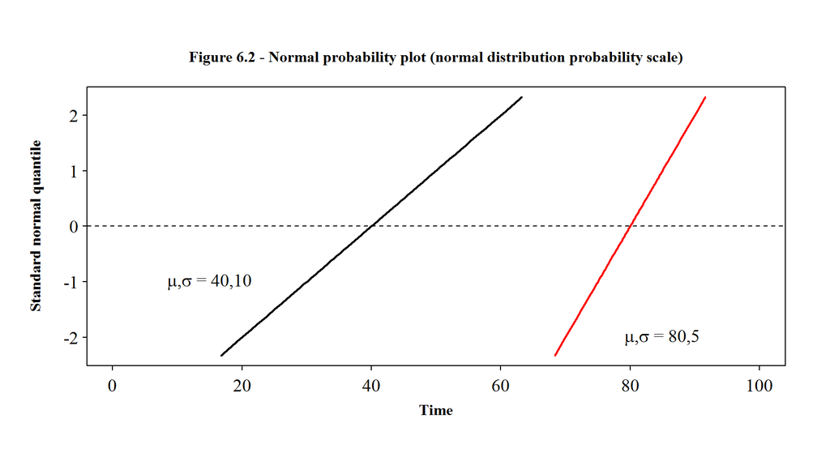

## Figure 6.2 - Normal Probability Plot

STAT 687 - Chapter 6

```r
par(family="serif",font=2,cex=1.15, bg = NA)
plot(qnorm(p,mean=40,sd=10),qnorm(p),type="l",lwd=2,col=1,
     xlim=range(0,100),axes=F,xlab="",ylab="")
par(new=TRUE)
plot(qnorm(p,mean=80, sd=5),qnorm(p),type="l",lwd=2,col=2,
     xlim=range(0,100),axes=F,xlab="",ylab="")

abline(h=0, lty=2)

text(15,-1, expression(mu*","*sigma*" = 40,10"))
text(85,-2, expression(mu*","*sigma*" = 80,5"))

box(lwd=1.25)
axis(side = 1, tck = -.015, labels = NA); axis(side = 2, tck = -.015, labels = NA)
axis(side = 1, lwd = 0, line = -.6);      axis(side = 2, lwd = 0, line = -.6, las = 1)

mtext(side = 1, "Time", line = 1.5)
mtext(side = 3,"Figure 6.2 - Normal probability plot (normal distribution probability scale)", line = 1)
mtext(side = 2,"Standard normal quantile", line = 2)
```

## $\S$ 6.2.3 - Linearizing the Lognormal CDF

STAT 687 - Chapter 6

For $T\sim LOGNOR(\mu,\sigma)$

$F(t_{p})=p=\Phi_{nor}\left[\frac{\log(t_{p})-\mu}{\sigma}\right] \;\;t_{p}\in [0,\infty)$

and

$\log(t_{p})=\Phi_{nor}^{-1}(p)\sigma +\mu$

**What points are being plotted?**

**How can we determine $\sigma$ from the best fit line?**

**How can we determine $\mu$ from the best fit line?**

## Figure 6.3 - Lognormal Probability Plot

STAT 687 - Chapter 6

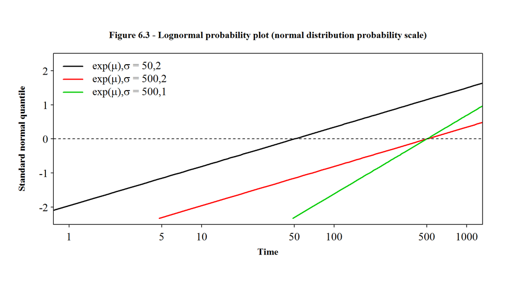

## Figure 6.3 - Lognormal Probability Plot

STAT 687 - Chapter 6

```r
par(family="serif",font=2,cex=1.15, bg = NA)
plot(qlnorm(p,m=log(50),sd=2),qnorm(p),type="l",lwd=2,col=1,xlim=c(1,1000),axes=F,xlab="",ylab="",log="x")
par(new=TRUE)
plot(qlnorm(p,m=log(500),sd=2),qnorm(p),type="l",lwd=2,col=2,xlim=c(1,1000),axes=F,xlab="",ylab="",log="x")
par(new=TRUE)
plot(qlnorm(p,m=log(500),sd=1),qnorm(p),type="l",lwd=2,col=3,xlim=c(1,1000),axes=F,xlab="",ylab="",log="x")

abline(h=0, lty=2)

box(lwd=1.25)
axis(side = 1, tck = -.015, labels = NA); axis(side = 2, tck = -.015, labels = NA)
axis(side = 1, lwd = 0, line = -.6);      axis(side = 2, lwd = 0, line = -.6, las = 1)

mtext(side = 1, "Time", line = 1.5)
mtext(side = 3,"Figure 6.3 - Lognormal probability plot (normal distribution probability scale)", line = 1)
mtext(side = 2,"Standard normal quantile", line = 2)

legend("topleft",c(expression("exp("*mu*"),"*sigma*" = 50,2"),
                   expression("exp("*mu*"),"*sigma*" = 500,2"),
                   expression("exp("*mu*"),"*sigma*" = 500,1")),
       lty=1,col=c(1,2,3),lwd=2, bty = "n")
```

## $\S$ 6.2.4 - Linearizing the Weibull cdf

STAT 687 - Chapter 6

For $T\sim WEIB(\beta,\eta)$

$F(t_{p})=p=1-\exp\left[-\left(\frac{t}{\eta}\right)^{\beta}\right]$

and

$\log\left[t_{p}\right]=\log\left(\log\left[\frac{1}{1-p}\right]\right)\frac{1}{\beta}+\log[\eta]$

**What points are being plotted?**

**How can we determine $\beta$ from the best fit line?**

**How can we determine $\eta$ from the best fit line?**

## Figure 6.4 - Weibull Probability Plot

STAT 687 - Chapter 6

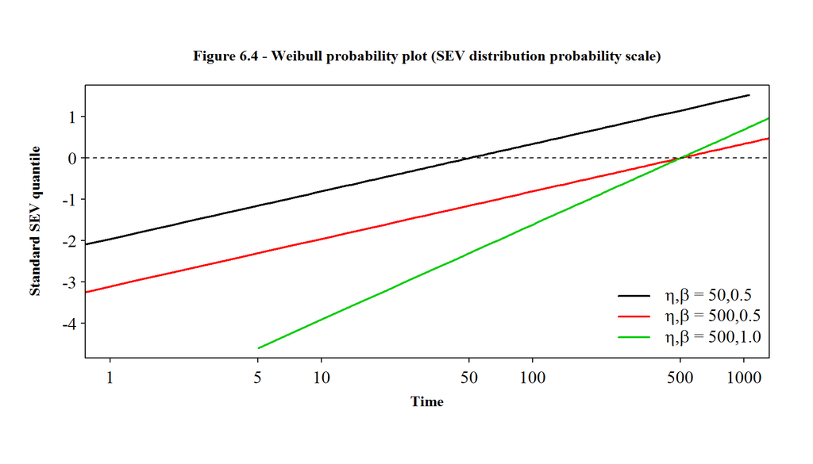

## Figure 6.4 - Weibull Probability Plot

STAT 687 - Chapter 6

```r
par(family="serif",font=2,cex=1.15, bg = NA)
plot(qweibull(p,.5,50),-qgumbel(1-p),type="l",lwd=2,col=1,xlim=c(1,1000),axes=F,xlab="",ylab="",log="x")
par(new=TRUE)
plot(qweibull(p,.5,500),-qgumbel(1-p),type="l",lwd=2,col=2,xlim=c(1,1000),axes=F,xlab="",ylab="",log="x")
par(new=TRUE)
plot(qweibull(p,1,500),-qgumbel(1-p),type="l",lwd=2,col=3,xlim=c(1,1000),axes=F,xlab="",ylab="",log="x")

abline(h=0, lty=2)

box(lwd=1.25)
axis(side = 1, tck = -.015, labels = NA); axis(side = 2, tck = -.015, labels = NA)
axis(side = 1, lwd = 0, line = -.6);      axis(side = 2, lwd = 0, line = -.6, las = 1)

mtext(side = 1, "Time", line = 1.5)
mtext(side = 3,"Figure 6.4 - Weibull probability plot (SEV distribution probability scale)", line = 1)
mtext(side = 2,"Standard SEV quantile", line = 2)

legend("bottomright",c(expression(eta*","*beta*" = 50,0.5"),
                       expression(eta*","*beta*" = 500,0.5"),
                       expression(eta*","*beta*" = 500,1.0")),
       lty=1,col=c(1,2,3),lwd=2, bty = "n")
```

## Probability Plots - Axis Comparison

STAT 687 - Chapter 6

# Section 6.3|Graphical Goodness of Fit

## $\S$ 6.3 - Graphical Goodness of Fit

STAT 687 - Chapter 6

Assessing the adequacy of a distribution’s fit for a data set is an important application of probability plots

Probability plots are created by

1. Identifying the points $\left(t_{i},\hat{F}(t_{i})=\hat{p}_{i}\right), \;\;\;\;i=1,2,...,n$
2. Plotting these points on axes that have been transformed for a distribution of interest
3. Observe if the data fall approximately on a straight line

We’ve already covered items 2) and 3), next we’ll discuss what value should be used for $\hat{p}$

# Section 6.4|Probability Plotting Postions

## $\S$ 6.4.1 - Criteria for Choosing Plotting Positions

STAT 687 - Chapter 6

Probability plots require a way to compute plotting positions $F(t_{i}), i=1,...,n$

Choosing a plotting position formula depends on the purpose of the plot

- Checking distributional assumptions
- Estimating distribution parameters

The best plotting position formula is a function of

- The assumed underlying model
- The function to be estimated $(t_{p}, h(t), F(t),...)$
- The type and amount of censoring

**Most texts oversimplify the choice of a plotting position formula**

## $\S$ 6.4.1 - Criteria for Choosing Plotting Positions

STAT 687 - Chapter 6

The generic plotting position formula is

$p_{i}=\frac{i-a}{n+1-2a}$

where

$\begin{aligned} i &\equiv\;\text{an index of the ordered observations (smallest}\rightarrow\text{largest)}\\ n &\equiv\;\text{the sample size}\\ a &\equiv\;\text{the plotting position parameter}\\ p_{i}&\equiv\;\text{the value of the plotting position corresponding to time}\; t_{i} \end{aligned}$

A value of $a$ is chosen to produce approximately unbiased estimates for $F(t_{i})$ for an assumed distribution

## Probability Plot Formula Table

STAT 687 - Chapter 6

$\begin{array}{ccccc} \hline \text{Proponent} & \text{Year} & \text{a} & \text{Formula} \\ \hline \text{Hazen} & 1914 & 0.50 & \frac{i-0.5}{n} \\ \hline \text{Weibull} & 1939 & 0 & \frac{i}{n+1} \\ \hline \text{Blom} & 1958 & 0.375 & \frac{i-0.375}{n+0.25} \\ \hline \text{Gringorten} & 1963 & 0.44 & \frac{i-0.44}{n+0.12} \\ \hline \text{Chegodayev} & 2000 & 0.30 & \frac{i-0.30}{n+0.4} \\ \hline \text{Cunnane} & 1977 & 0.40 & \frac{i-0.40}{n+0.2} \\ \hline \text{Median} & 1943 & 0.3175 & \frac{i-0.3175}{n+0.365} \\ \hline \end{array}$

## $\S$ 6.4.1 - Criteria for Choosing Plotting Positions

STAT 687 - Chapter 6

Except for specialized situations, the plotting positions used in practice are

$\begin{aligned} \text{Hazen}\; &p_{i}=\frac{i-0.5}{n}\\\\ \text{Chegodayev}\; &p_{i}=\frac{i-0.3}{n+0.4}\;\text{also known as "Median-Ranks"}\\\\ \text{Weibull}\; &p_{i}=\frac{i}{n+1}\\\\ \end{aligned}$

Plotting positions for this text

$p_{i}=\begin{cases}\frac{i}{n}, &\mbox{Distribution free - (Eq 3.1)}\\\\ \frac{i-0.5}{n}, &\mbox{Assumed distribution}\end{cases}$

## $\S$ 6.4.2 - Choice of Plotting Positions

STAT 687 - Chapter 6

Censoring considerations for selecting a plotting position formula

1. Continuous inspection or small inspection intervals
2. Interval censoring with large intervals
3. Arbitrary censoring
   - Left censoring
   - Right censoring
   - Interval censoring
   - Overlapping intervals

## $\S$ 6.4.2 - Choice of Plotting Positions

STAT 687 - Chapter 6

**Case 1 - Data with continuous inspection and a single censoring event**

A logical estimator is

$\hat{p}_{i}=\frac{i}{n}$

Estimator properties

- Increases by $\frac{1}{n}$ at each failure time $t_{i}$
- Underestimates $F(t)$ prior to the first failure time at $t_{1}$
- Overestimates $F(t)$ after the last failure time at $t_{n}$

**The meekR package uses this estimator for `plot(data.ld)`**

## $\S$ 6.4.2 - Choice of Plotting Positions

STAT 687 - Chapter 6

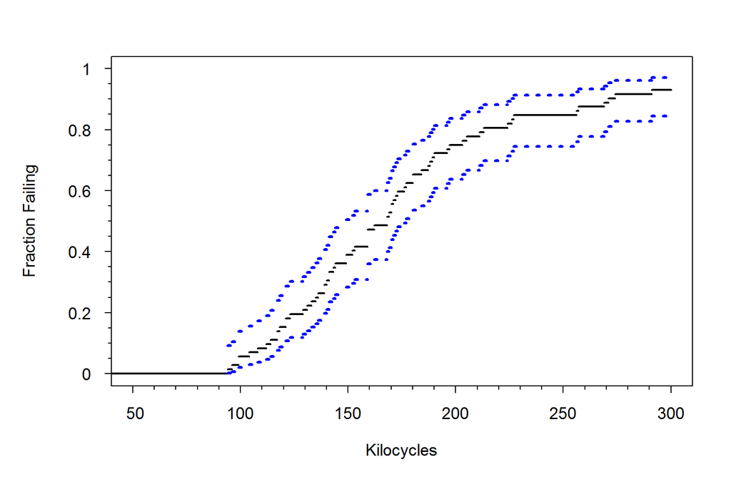

## $\S$ 6.4.2 - Choice of Plotting Positions

STAT 687 - Chapter 6

A compromise plotting position for addressing this bias uses midpoint of the $1/n$ jumps

$\hat{p}_{i}=\frac{i-0.5}{n}=\frac{1}{2}\left[\hat{F}(t_{(i)})+\hat{F}(t_{(i-1)})\right]$

**The meekR package uses this comprimise estimator for `plot(data.ld, distribution = "distribution")`**

## $\S$ 6.4.2 - Choice of Plotting Positions

STAT 687 - Chapter 6

## R Code for Figures 6.5 - 6.7

STAT 687 - Chapter 6

**Figure 6.5**

```r
at7987.ld <- frame.to.ld(at7987,
                         response.column = 1,
                         censor.column = 2,
                         case.weight.column = 3,
                         data.title = "Alloy t7987 Data",
                         time.units = "Thousand Cycles")
plot(at7987.ld)
```

**Figure 6.6**

```r
plot(at7987.ld,distribution="Weibull")
```

[output not shown]

**Figure 6.7**

```r
plot(at7987.ld,distribution="Lognormal")
```

[output not shown]

## $\S$ 6.4.2 - Choice of Plotting Positions

STAT 687 - Chapter 6

**Case 2 - Data with continuous inspection and multiple right censoring events**

For this case, each failure can result in a jump that is larger that $1/n$

- Censored observations between failures will reduce $n$
- Furthermore, $\frac{i-0.5}{n}\ne\frac{1}{2}\left[\hat{F}(t_{(i)})+\hat{F}(t_{(i-1)})\right]$

For this case, we use the estimated values $\hat{F}(t_{(i)})$ directly as

$\hat{p_{i}}=\frac{1}{2}\left[\hat{F}(t_{(i)})+\hat{F}(t_{(i-1)})\right]$

where $\hat{F}(t_{(i)})\;\text{and}\;\hat{F}(t_{(i-1)})$ are computed using Eqs. 3.6 & 3.7.

## $\S$ 6.4.2 - Choice of Plotting Positions

STAT 687 - Chapter 6

Recall from Eq. 3.7

$\hat{F}(t_{i})=1-\prod_{j=1}^i \left[1-\hat{p}_{j}\right]=1-\prod_{j=1}^i \left[1-\frac{d_j}{n_j}\right]$

Therefore,

$\begin{aligned} p_i=\frac{1}{2}\left[1-\prod_{j=1}^i \left[1-\frac{d_j}{n_j}\right]+1-\prod_{j=1}^{i-1} \left[1-\frac{d_j}{n_j}\right]\right] \end{aligned}$

## Example 6.3 - ShockAbsorber

STAT 687 - Chapter 6

## $\S$ 6.4.2 - Choice of Plotting Positions

STAT 687 - Chapter 6

**Case 3 - Data with Interval censoring**

- Failures “occur” at the end of an interval when discovered by inspection
- $\hat{F}(t)$ defined as the upper endpoint of an interval in which failures occurred
- For this case, the plotting position is

$p_{i}=\hat{F}(t_{(i)})$

Where

- $E\left[\hat{F}(t_{(i)})\right]=F(t_{(i)})$ when there are no losses due censoring
- $E\left[\hat{F}(t_{(i)})\right]\approx F(t_{(i)})$ when multiple censoring does occur

## Example 6.4 - Heat Exchanger

STAT 687 - Chapter 6

## $\S$ 6.4.2 - Choice of Plotting Positions

STAT 687 - Chapter 6

**Case 4 - Arbitrary censoring**

Data with arbitrary censoring can consist of a mixture of

- Left censored observations
- Right censored observations
- Exact failures

The plotting positions for arbitrarily censored data $\hat{F}(t)$ are computed using the formulas for the other cases

## Example 6.5 - Turbine Wheel

STAT 687 - Chapter 6

# Section 6.5|Probability Plots with Specified Shape Parameters

## $\S$ 6.5.1 - Linearizing the Gamma CDF

STAT 687 - Chapter 6

## $\S$ 6.5.2 - Linearizing the Weibull cdf using a linear time scale and specified shape parameter

STAT 687 - Chapter 6

## $\S$ 6.5.3 - Linearizing the generalized gamma cdf

STAT 687 - Chapter 6

## $\S$ 6.5.4 - Summary of prob. plotting methods

STAT 687 - Chapter 6

# Section 6.6|Notes on the Application of Probability Plotting

## $\S$ 6.6.1 - Using simulation to interpret prob. plots

STAT 687 - Chapter 6

## $\S$ 6.6.2 - Reasons for bends in prob. plots

STAT 687 - Chapter 6

Sharp bends or departures from linearity could indicate the existence of

- Multiple failure modes
- Different usage patterns in the sample
- An unexpected or unaccounted stressor

For this reason reliability data should include

- The failure mode(s) observed
- Variations in the usage environment
- Variations in the amount of usage

## Example 6.9 - Bleed System Failure

STAT 687 - Chapter 6

## Example 6.9 - Bleed System Failure

STAT 687 - Chapter 6

```r
Bleed.ld <- frame.to.ld(bleed,
                        response.column = 1,
                        censor.column = 2,
                        case.weight.column = 3,
                        x.columns = c(4),
                        data.title = "Bleed Failure Data",
                        time.units = "Hours")
stressor.ld(Bleed.ld, stress.var = "D")
```

[output not shown]

```
##
## Saving subset data object Bleed.DBase.ld
```

```r
stressor.ld(Bleed.ld, stress.var = "Other")
```

[output not shown]

```
##
## Saving subset data object Bleed.OtherBase.ld
```

## Example 6.9 - Bleed System Failure (Base: D)

STAT 687 - Chapter 6

## Example 6.9 - Bleed System Failure (Base: Other)

STAT 687 - Chapter 6